# Bioestadística, Zootecnia

Clase 1: Introducción a la investigación y la estadística

Departamento de Estadı́stica, Sede Bogotá

## Andrés Felipe Flórez Rivera

**Correo:** afflorezr@unal.edu.co

**Oficina:** 405-329

**Horario de atención:** Martes, 16h – 18h

## Contenido

### Investigación

- Qué es la investigación.
- Características principales.
- Pasos del proceso investigativo.
- Observación, pregunta e hipótesis.
- Experimentación, análisis y conclusiones.

### Tipos de investigación

- Según el enfoque.
- Según el alcance.
- Investigación cuantitativa, cualitativa y mixta.

### Alcance del estudio

- Investigación exploratoria y descriptiva.
- Investigación correlacional y explicativa.
- Resumen general de enfoques.

### Fundamentos de estadística

- Definiciones iniciales.
- Estadística descriptiva e inferencial.
- Variables y escalas de medición.

## Pasos y tipo de investigación

### ¿Qué es la investigación?

- Es un proceso organizado que busca **responder preguntas** o resolver problemas mediante la recolección y análisis de datos.
- La investigación permite generar conocimiento y tomar decisiones en cualquier disciplina.

## Características de la investigación

- Es ordenada (sigue pasos).
- Es objetiva (se basa en datos, no en opiniones).
- Es verificable (otros pueden replicar el proceso).
- Busca resolver problemas o generar conocimiento.

### Por ejemplo:

- **Zootecnia**: mejora de lotes, dietas y producción.
- **Biología**: estudio de organismos y ecosistemas.
- **Salud**: desarrollo de tratamientos y medicamentos.
- **Economía**: análisis de mercados y producción.
- **Medio ambiente**: evaluación del impacto ambiental.

## Pasos de la investigación

Los pasos de la investigación son un conjunto de etapas organizadas y secuenciales que guían el proceso científico desde la identificación de un problema hasta la obtención de conclusiones basadas en datos.

### Este proceso permite:

- Garantizar orden y coherencia.
- Obtener resultados confiables.
- Generar conocimiento válido.
1. Observación del problema.
2. Planteamiento de la pregunta.
3. Formulación de hipótesis.
4. Experimentación.
5. Análisis de datos.
6. Toma de decisiones.

## Observación del problema

Es la identificación y **descripción inicial** de una situación, **fenómeno** o **problema** que requiere ser estudiado.

Implica **observar la realidad de manera crítica**, detectar patrones o cambios relevantes y **delimitar qué aspecto específico se desea analizar**, sirviendo como punto de partida para todo el proceso de investigación.

#### Ejemplos:

- Disminución de la producción pecuaria.
- Bajo rendimiento académico.
- Aumento de casos de una enfermedad en una población.

## Planteamiento de la pregunta

Es el paso en el que se **formula** de manera clara, específica y medible lo que se **desea investigar**. Implica transformar el problema identificado en una **pregunta concreta**, delimitando:

- la población o fenómeno de interés.
- las variables involucradas.
- el posible tipo de relación entre ellas.

#### Se plantean preguntas como:

- ¿Cómo influye el suplemento en la producción?
- ¿Qué factores afectan el rendimiento académico?

## Formulación de hipótesis

Es la propuesta de una **explicación tentativa** o posible respuesta a la pregunta de investigación.

Se basa en conocimientos previos, teoría o evidencia, y establece una relación esperada entre variables, que posteriormente será evaluada con datos permitiendo:

- Orientar el diseño del estudio
- Definir qué variables se deben medir
- Permitir la verificación mediante análisis estadístico

#### Algunas hipótesis pueden ser:

- El suplemento aumenta la producción.
- El suplemento aumenta en 5 % la ganancia diaria de peso.

## Experimentación

Define cómo se obtendrán los datos para evaluar la hipótesis. Implica diseñar un procedimiento sistemático para recolectar información, controlando las condiciones y asegurando que los datos sean válidos y confiables.

#### ¿Qué implica?

- Seleccionar el tipo de estudio (experimental u observacional)
- Definir la población o muestra
- Establecer las variables a medir

#### Ejemplos

- Comparar el crecimiento de aves usando distintos tipos de suplemento.
- Evaluar el efecto de distintos niveles de suplementación en la ganancia de peso.
- Evaluar el efecto de distintos tipos de dieta en el crecimiento de animales.

## Análisis de datos

Se organizan, procesan e interpretan los datos recolectados. Implica aplicar **herramientas estadísticas** para **resumir** la información, **identificar** patrones o tendencias, **explorar** relaciones entre variables y evaluar la hipótesis planteada.

#### Ejemplos

- Elaborar tablas de frecuencia y gráficos.
- Calcular medidas descriptivas.
- Hacer comparaciones, por ejemplo, comparar productividades entre tratamientos.

## Conclusiones y toma de decisiones

Se interpretan los resultados obtenidos y se responde la pregunta de investigación. Se analiza la evidencia para aceptar o rechazar la hipótesis y tomar decisiones basadas en los datos.

#### ¿Qué implica?

- Interpretar los resultados del análisis.
- Evaluar si la hipótesis es consistente con los datos.
- Formular conclusiones claras y justificadas.
- Apoyar la toma de decisiones con evidencia.

#### Ejemplos

- El ambiente de estudio adecuado mejoró el rendimiento académico.
- Se determina cuál tratamiento aumenta la producción.

## Ilustración:

- Problema: baja ganancia de peso bovina
- Pregunta: ¿El suplemento mejora la producción?
- Hipótesis:

  $$H_{0}: \mu_{suplementado} - \mu_{sin-suplementar} = 0$$

  $$H_{1}: \mu_{suplementado} - \mu_{sin-suplementar} > 0$$
- Experimentación: manejo en corrales con y sin suplemento.
- Análisis: comparación de medias (ANOVA)
- Conclusión: determinar si el suplemento mejora la producción

## Tipos de investigación

## Enfoque y Alcance

#### Investigación según enfoque

La investigación según enfoque se refiere a **la forma** en que se **recolectan**, **analizan** e **interpretan** los **datos** para estudiar un fenómeno.

- **Ejemplo:** analizar las notas de un grupo de estudiantes para calcular el promedio y representar los resultados con gráficos.

#### Investigación según alcance

La investigación según alcance se refiere al **nivel de profundidad** o hasta dónde se quiere llegar **en el estudio** de un fenómeno. Es decir, indica qué tanto se va a investigar o explicar.

## Investigación según enfoque

Indica cómo se realiza el estudio. Es decir, el enfoque determina si la investigación:

- **Usa datos numéricos:** Enfoque cuantitativo.
- **Usa descripciones:** Enfoque cualitativo.
- **Combina ambos (datos numéricos y descripciones):** Enfoque mixto.

## Según enfoque: investigación cuantitativa

Es un tipo de investigación que se basa en la recolección y **análisis de datos numéricos** para responder preguntas o comprobar hipótesis. Utiliza mediciones, cálculos y herramientas estadísticas.

#### Ejemplo:

- **Pregunta:** ¿El tiempo de estudio influye en las calificaciones?
- **Datos:** horas de estudio y notas.
- **Análisis:** comparación de promedios.
- **Resultado:** se determina si existe relación entre ambas variables.

## Según enfoque: investigación cualitativa

Es un tipo de investigación que busca describir y comprender fenómenos a partir de observaciones, percepciones o experiencias, **sin centrarse en mediciones numéricas**.

#### Ejemplo:

- Describir el estado de los animales (color, aspecto, daño).
- Identificar tipos de dieta según sus características.
- Registrar la presencia de enfermedades y su comportamiento.

*No busca medir cuánto, sino comprender cómo y por qué ocurre un fenómeno.*

## Según enfoque: Investigación mixta

Es aquella que combina el enfoque cuantitativo y cualitativo, utilizando tanto datos numéricos como descriptivos para obtener un análisis más completo.

#### Ejemplo:

- Medir la producción del lote (cuantitativa).
- Evaluar características del lote como color, tamaño o presencia de enfermedades (cualitativa).
- Estudiantes con más horas de estudio (cuantitativa).
- Percepción de la calidad educativa (cualitativa).

*No es hacer dos estudios separados, sino integrar ambos en uno solo.*

## Investigación según alcance

Se refiere al nivel de profundidad o hasta dónde se quiere llegar en el estudio de un fenómeno. Es decir, indica qué tanto se va a investigar o explicar, pudiendo ser:

- **Exploratoria**: se aproxima al problema y lo reconoce.
- **Descriptiva**: caracteriza el fenómeno.
- **Correlacional**: analiza la relación entre variables.
- **Explicativa**: identifica causas y efectos.

## Según alcance: investigación exploratoria

Es un tipo de investigación que se realiza cuando el problema **ha sido poco estudiado** o **existe escasa información**. Su propósito es comprender el fenómeno, identificar variables relevantes y generar ideas para estudios posteriores. No busca conclusiones definitivas, sino:

- Explorar el problema
- Identificar posibles variables
- Plantear preguntas e hipótesis iniciales

#### Algunos ejemplos:

- Investigar tendencias de consumo en un mercado emergente.
- Explorar hábitos de vida en una población poco estudiada.
- Identificar la presencia de una enfermedad desconocida.

## Según alcance: investigación descriptiva

Tiene como objetivo detallar y caracterizar un fenómeno, identificando sus propiedades, características y comportamientos. Se enfoca en responder preguntas como ¿**cómo es**?, ¿**cómo se presenta**? y ¿**qué características tiene**?, sin buscar explicar sus causas.

- Se usa cuando el fenómeno ya es conocido
- Busca detallar y caracterizar
- Resultado: información organizada del fenómeno

#### Algunos ejemplos:

- Analizar características de la dieta (textura, humedad).
- Analizar características demográficas de una población.
- Describir el rendimiento académico de estudiantes.

## Según alcance: investigación correlacional

La investigación correlacional tiene como objetivo **identificar y medir la relación entre dos o más variables**, evaluando si estas cambian de manera conjunta. Es importante destacar que **no establece relaciones de causa y efecto**, sino que únicamente indica la existencia de asociación entre ellas.

- Analiza la relación entre variables
- Evalúa si las variables cambian conjuntamente
- Permite identificar asociaciones entre fenómenos

#### Algunos ejemplos:

- Relación entre lluvia y producción pecuaria.
- Relación entre uso de suplemento y crecimiento de animales.
- Relación entre temperatura y desarrollo del animal.

## Según alcance: investigación explicativa

La investigación explicativa busca **identificar las causas de un fenómeno**, explicando por qué ocurre y bajo qué condiciones, mediante el establecimiento de relaciones de causa y efecto.

- Busca causas.
- Responde por qué ocurre.
- Suele implicar experimentos o diseños más rigurosos.

#### Algunos ejemplos:

- Estudiar las causas de una enfermedad.
- Determinar por qué un suplemento aumenta la producción.
- Analizar las causas de una enfermedad en un lote.
- Evaluar el efecto de la alimentación en el crecimiento de animales.

## Resumen enfoque cuantitativo

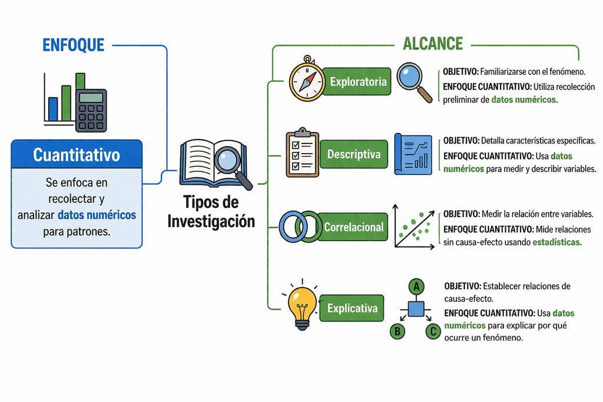

## Resumen enfoque cualitativo

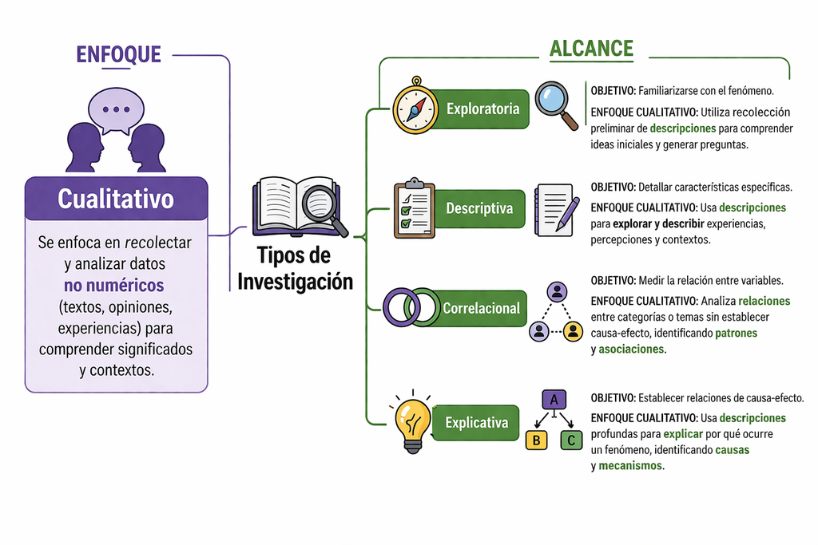

## Conclusiones

La investigación es un proceso que permite generar conocimiento a partir del análisis de datos.

#### Según enfoque (cómo se investiga)

- **Cuantitativo**: mide fenómenos con datos numéricos.
- **Cualitativo**: describe y comprende características.
- **Mixto**: combina ambos enfoques

## Definiciones Iniciales en estadística

## ¿Qué es la estadística?

**Note**

- Es una rama de las matemáticas que permite **recolectar, analizar e interpretar datos**.
- Es fundamental en la ciencia para **tomar decisiones basadas en evidencia**.
- Se basa en el estudio de **muestras** para hacer inferencias sobre **poblaciones**.

## Tipos de estadística

La estadística se divide en dos grandes ramas:

#### Estadística descriptiva

La estadística descriptiva es la rama de la estadística que se encarga de **organizar**, **resumir** y **presentar datos**, utilizando **tablas**, **gráficos** y medidas numéricas como la **media**, **mediana**, **moda**, **varianza** y **desviación estándar**, con el fin de describir sus características sin realizar generalizaciones.

- **Ejemplo:** promedio de notas, histogramas, tablas de frecuencia.

#### Estadística inferencial

La estadística inferencial es la rama de la estadística que permite obtener conclusiones y tomar decisiones sobre una población a partir de una muestra, mediante el uso de medidas como estimaciones, intervalos de confianza, pruebas de hipótesis y modelos probabilísticos.

- Estimar el promedio de estudiantes de toda una universidad.
- Evaluar si un medicamento es efectivo.
- Realizar una prueba de hipótesis.

## Descriptiva vs Inferencial

Los tipos de Estadística, **descriptiva** e **inferencial**, son **complementarios** en el análisis de datos:

- La primera permite organizar, resumir y comprender la información mediante medidas numéricas.
- La segunda posibilita interpretar, generalizar resultados y tomar decisiones sobre una población.

La estadística descriptiva resume los datos, mientras que la inferencial permite sacar conclusiones y tomar decisiones, siendo ambas esenciales en el análisis cuantitativo.

## Definiciones Iniciales en estadística

#### Bioestadística

Es una herramienta fundamental para el análisis de datos en las **ciencias de la vida**, ya que permite interpretar **fenómenos biológicos**, evaluar procesos de salud y optimizar la producción pecuaria mediante el uso de métodos estadísticos. Su **aplicación** en áreas como la **medicina**, la *biología* y la **Zootecnia** contribuye a la toma de decisiones basadas en evidencia y al desarrollo científico.

## Definiciones Iniciales en estadística

#### Población

Es el conjunto total de elementos, individuos o unidades de estudio que comparten una o varias características de interés dentro de una investigación. La población puede ser finita o infinita y constituye el universo sobre el cual se desean obtener conclusiones. A seguir algunos ejemplos:

- Todos los estudiantes de una universidad.
- Todos los lotes de bovinos en una granja.
- Todos los pacientes de un hospital.
- Todos los habitantes de una ciudad.

## Definiciones Iniciales en estadística

#### Muestra

Es un **subconjunto** representativo de la **población**, seleccionado con el propósito de **analizar** sus **características** y hacer **inferencias** sobre el total de la población, especialmente cuando no es posible estudiar todos sus elementos, por ejemplo:

- 100 estudiantes seleccionados.
- 20 corrales de un lote analizados.
- 50 pacientes encuestados.
- 200 personas de una ciudad.

## Definiciones Iniciales en estadística

#### Censo

Un censo es un método de recolección de datos que consiste en estudiar y obtener información de todos los elementos que conforman una población, sin recurrir a muestras, con el fin de describir sus características de manera completa y precisa.

- Contar todos los habitantes de un país.
- Evaluar todos los lotes de una granja.
- Analizar todos los empleados de una empresa.

## Definiciones Iniciales en estadística

#### Variable

Es una **característica** o **atributo** que puede tomar diferentes valores en los elementos de una población o muestra. Las variables pueden ser **cualitativas** o **cuantitativas**, y son la base para el análisis estadístico.

- Edad.
- Estatura.
- Tipo de lote.
- Nivel de ingreso.

## Definiciones Iniciales en estadística

#### Dato

Los datos constituyen la **materia prima** del análisis estadístico y pueden presentarse en forma numérica o categórica.

- Edad = 21 años
- Estatura = 1.70 m
- Peso = 65 kg
- Lote = bovinos

## Definiciones Iniciales en estadística

#### Parámetro

Es una **medida numérica** que describe una característica de la población, como la media o la proporción, y generalmente es desconocida, por lo que se **estima a partir de una muestra**.

- Promedio de edad de todos los estudiantes.
- Producción promedio de toda una granja.
- Porcentaje total de pacientes recuperados.
- Ingreso promedio de una ciudad.

## Definiciones Iniciales en estadística

#### Estadístico

Es una medida numérica calculada a partir de los datos de **una muestra**, utilizada para describirla y para estimar parámetros poblacionales.

- Promedio de edad de 100 estudiantes.
- Producción promedio de 20 corrales.
- Porcentaje de recuperación en 50 pacientes.
- Ingreso promedio de 200 personas.

## Tipos de variables

Las variables son **características o atributos** que pueden asumir distintos valores en los elementos de una **población o muestra**. Constituyen un elemento fundamental del análisis estadístico, ya que permiten describir, comparar y establecer relaciones entre los datos. De acuerdo con su naturaleza, se clasifican en **variables cuantitativas** y **cualitativas**.

## Tipos de variables

#### Variables cuantitativas

Las variables cuantitativas se atribuyen a **mediciones numéricas** y se pueden clasificar en:

- Cuantitativa continua.
- Cuantitativa discreta.

## Tipos de variables

#### Cuantitativa continua

Es una variable que puede tomar **cualquier valor** dentro de **un intervalo de números reales**, incluyendo valores decimales, ya que resulta de mediciones. Este tipo de variable se caracteriza por tener infinitos valores posibles entre dos puntos.

- Peso.
- Promedio académico.
- Temperatura corporal.
- Altura.

## Tipos de variables

#### Cuantitativa discreta

Es aquella que toma valores numéricos enteros y contables, sin admitir valores intermedios o decimales, ya que resulta de un proceso de conteo.

- Número de hijos.
- Número de estudiantes en un salón.
- Cantidad de carros en un parqueadero.
- Número de llamadas recibidas.

## Tipos de variables

#### Variables cualitativas

Son variables que no toman valores numéricos sino que se refieren a atributos, clases o categorías y pueden clasificarse en nominales y ordinales.

- Cualitativa nominal.
- Cualitativa ordinal.

## Tipos de variables

#### Cualitativa nominal

Son atributos que se clasifican en grupos, pero ninguno es mayor o mejor que otro.

- Color de ojos.
- Color de la ave.
- Género.
- Tipo de dieta.

## Tipos de variables

#### Cualitativa ordinal

Son variables donde la categoría tiene un orden o una jerarquía.

- Nivel de calidad (bajo, medio, alto).
- Clasificaciones (oro, plata, bronce).
- Rendimiento académico (insuficiente, regular, bien, muy bien, excelente).

## Tipos de variables

#### Clasifiquemos las siguientes variables:

- Peso del recién nacido: variable cuantitativa continua.
- Número de hojas: variable cuantitativa discreta.
- Peso de los animales: variable cuantitativa continua.
- Color de ojos: variable cualitativa nominal.
- Nivel de satisfacción: variable cualitativa ordinal.
- Peso del fruto: variable cuantitativa continua.

## Escalas de medición

Las escalas de medición son sistemas que **permiten clasificar y cuantificar las variables** de acuerdo con la naturaleza de la **información que representan**. Estas establecen las posibilidades de análisis de los datos. Las escalas de medición más utilizadas son:

- Escala nominal.
- Escala ordinal.
- Escala de intervalo.
- Escala de razón.

## Escalas de medición

#### Escala nominal

La escala nominal clasifica los datos en categorías sin un orden.

- Tipo de lote: bovinos, aves, ganado.
- Presencia de enfermedad: sí, no.
- Tipo de sangre: A, B, AB, O.

## Escalas de medición

#### Escala ordinal

La escala ordinal clasifica los datos en categorías con orden, pero sin medir la diferencia exacta entre ellas.

- Nivel de calidad: bajo, medio, alto.
- Clasificación: primer lugar, segundo lugar, tercer lugar.
- Nivel de humedad: bajo, medio, alto.

## Escalas de medición

#### Escala de intervalo

La escala de intervalo permite medir diferencias entre valores, pero no tiene un cero real. Aquí es importante notar que **el cero no significa ausencia total.**

- Temperatura en grados Celsius o Fahrenheit.
- Años del calendario.
- Hora del día.

## Escalas de medición

#### Escala de razón

La escala de razón permite diferencias y además tiene un cero real (ausencia total).

- Peso del animal.
- Ingresos.
- Edad.

## Escalas de medición

#### Clasifiquemos las siguientes variables según su escala de medición:

- Color de ojos: escala nominal.
- Nivel de satisfacción (bajo, medio, alto): escala ordinal.
- Temperatura (°C): escala de intervalo.
- Edad: escala de razón.
- Tipo de sangre: escala nominal.
- Ingreso mensual: escala de razón.